# Tidybiology Final Project

CHELSEA SHOBEN

October 21, 2019

### 1) Load libraries

##### My personal motivations: Explore genes and/or regions of genome relationship with temperature dependence. (attributes of interest based on my current project exploring thermal plasticity of meiotic recombinaion rates)

## Attempt #1 (uniprot)

This data was pulled from uniport.com, I selected reviewed, D. melanogaster, gene name, length, mass, natural variant information, and temperature dependence data. The last part was becasue this is relevant for my current project in lab lookig at recombination rates across different thermal regimes across a group of inbred flies secured from a single, wild population.

Great practice, but low number of resulting temperature dependent genes extinguished my curiosity in continuing to explore this data set.

## Attempt #2 (tidybiology data)

### 2) Import data

Human ‘genes’ data from the Tidybiology package.

### 3) Take a `glimpse` into the data in the dataframe

```r
glimpse(genes)
```

```
## Observations: 61,187
## Variables: 10
## $ gene_name                <chr> "DDX11L1", "WASH7P", "MIR6859-1", "MIR1…
## $ gene_description         <chr> "DEAD/H-box helicase 11 like 1", "WASP …
## $ chromosome_scaffold_name <chr> "1", "1", "1", "1", "1", "1", "1", "1",…
## $ strand                   <dbl> 1, -1, -1, 1, 1, -1, 1, 1, 1, -1, -1, 1…
## $ transcript_start_bp      <dbl> 11869, 14404, 17369, 29554, 30366, 3455…
## $ transcript_end_bp        <dbl> 14409, 29570, 17436, 31097, 30503, 3608…
## $ transcript_length        <dbl> 1657, 1351, 68, 712, 138, 1187, 840, 14…
## $ gene_percent_gc_content  <dbl> 57.50, 54.43, 61.76, 48.84, 31.16, 50.2…
## $ gene_stable_id           <chr> "ENSG00000223972", "ENSG00000227232", "…
## $ transcript_stable_id     <chr> "ENST00000456328", "ENST00000488147", "…
```

Columns include information on gene name, description, chromosome, forward/reverse strand, transcript start/stop and total length, gc percentage, and additional id values.

### 4) EDA

EXPLORATORY DATA ANALYSIS

Mutated the dataframe to have a boolean for if a gene description included the word ‘heat’ or not.

### 5) EDA Graph

Exploratory Data Analysis Graph

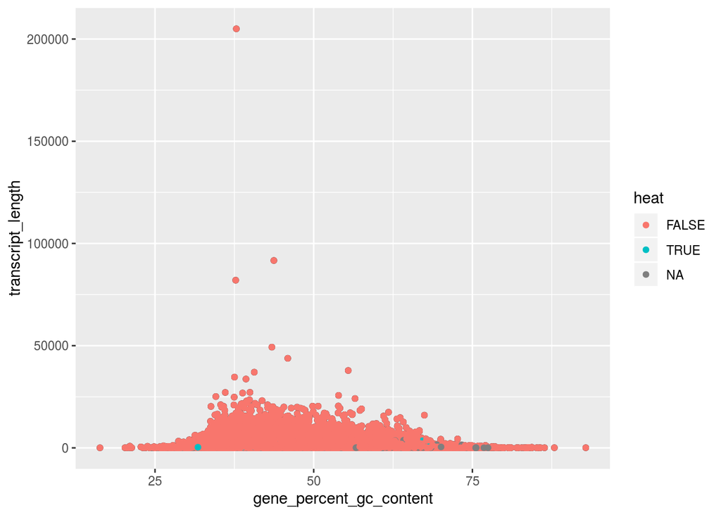

Too many dots!

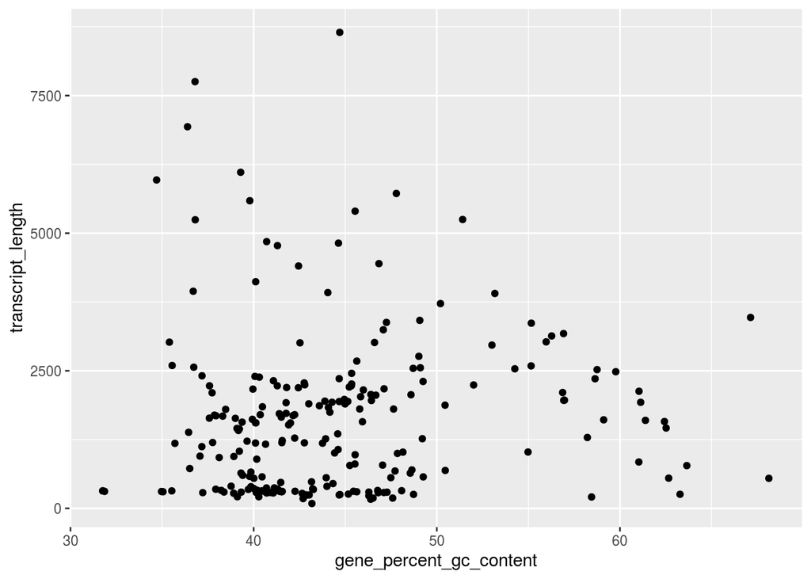

I thought it would be neat to categorize the heat related genes based on if ‘pseudogene’ is included in their description.

### 6) Final Graph

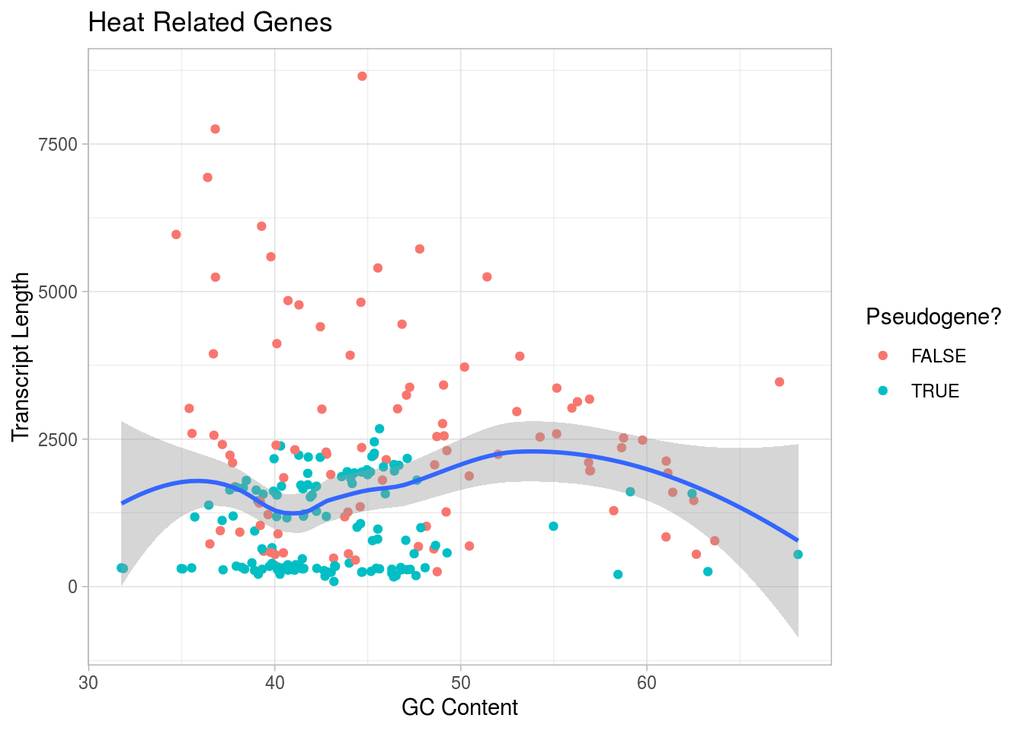

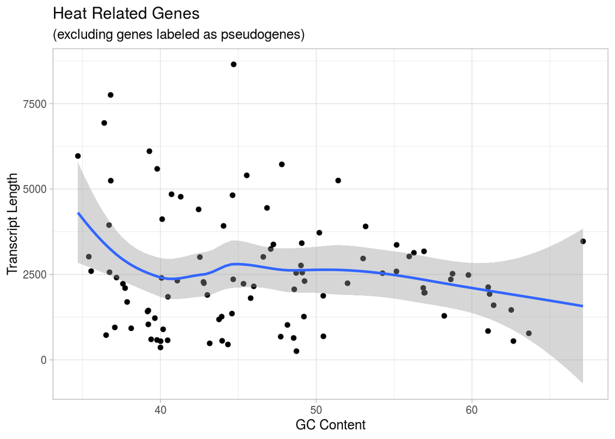

```r
genesheatNOPseudo <- genesheat %>%
  filter(pseudo == FALSE)
```

## Round 3?

### I really wanted to see if there is a connection between chromosome location, GC content, and heat related genes.

## EDA Graph

```r
unique(genes$chromosome_scaffold_name)
```

```
##   [1] "1"                              "1_1_CTG11"
##   [3] "1_1_CTG3"                       "1_1_CTG31"
##   [5] "1_1_CTG32_1"                    "1_2_CTG3"
##   [7] "1_2_CTG31"                      "1_3_CTG3"
##   [9] "1_3_CTG31"                      "1_3_CTG32_1"
##  [11] "1_4_CTG3"                       "1_4_CTG31"
##  [13] "1_5_CTG3"                       "1_5_CTG32_1"
##  [15] "1_6_CTG3"                       "1_8_CTG3"
##  [17] "1_9_CTG3"                       "1_ALT2_1_CTG32_1"
##  [19] "10"                             "10_1_CTG1"
##  [21] "10_1_CTG2"                      "10_1_CTG3"
##  [23] "10_1_CTG4"                      "11"
##  [25] "11_1_CTG1_2"                    "11_1_CTG3_1"
##  [27] "11_1_CTG5"                      "11_1_CTG6"
##  [29] "11_1_CTG7"                      "11_1_CTG8"
```

[output cut: 186 more lines]

```r
#so many categories!
```

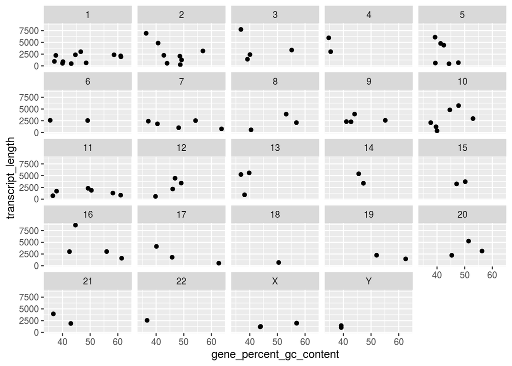

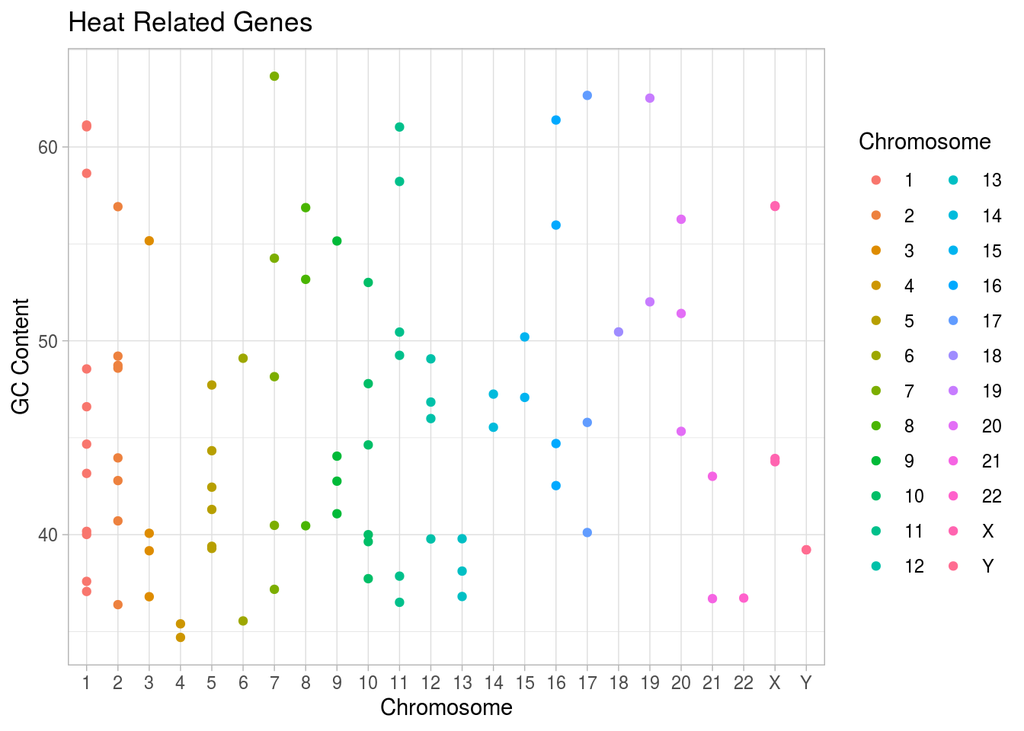

## Conclusions

My exploring has shown me:

- No correlation between GC content and transcript length of genes labled to be involved with ‘heat’.
- Location of heat related genes not biased to a particular chromosome.

## Prioritized follow-up studies

I’d be interested in exploring if the lack of relationship displayed in my last graph is because I did not normalize my chromosome length. Being that I work with D. Melanogaster, I think it would make the most sense to do what I did above with genes in melanogaster.

## Acknolwedgements

Stackoverflow Hirschey squad (Matt, Allie, and Akshay) Kari and Maidson

#Session information for provenance and reproducibility